# Understanding the Influence of Funding on Academic Performance in Public Schools

Drew Howell

3/23/2019

## Final Project Report

###Introduction It is generally understood that funding has a positive causal relationship with academic performance in public schools. Public school systems with more funding can do more things to enhance the student’s academic experience, including widening the availability of learning tools and resources and ensuring higher sustained teacher morale (therefore lowering burnout), for example.

With that knowledge as a foundation, it is the goal of this project to further detail the interaction of public school funding and academic performance on a state-by-state granularity using statistical modelling on data from the public domain and to compare which type of algorithm lends itsself best to predicting a state’s academic progress.

###Data and Sources The data for this project was downloaded from the National Center for Education Statistics (NCES) and the U.S. Census Bureau. The specific datasets and their sources are listed below.

- Demographic data about the number of students enrolled in public schools (and the grades therein) for each state. Source: NCES
- Financial data about state revenue and expenditures for public education. Source: U.S. Census Bureau
- Performance data about test scores from the 4th and 8th grade NAEP (National Assessment of Educational Progress) exams. Source: NCES

All datasets include data dating back from 1996 to 2017.

These raw datasets are joined using Python code from a Kaggle user. The final dataset is read into this program as a CSV file named “states_all.csv”.

###The Program The rest of this report describes the program through the comments, “prologues”, and the code itsself, thereby detailing the data mining approaches, results, and interpretations/conclusions.

First, we read in the necessary libraries of functions.

```r
# for reading in source data
library(readr)
```

```r
# for plotting data
library(ggplot2)
# for getting percentile ranks to discretize dataset into thirds based on performance scores
library(dplyr)
# for decision tree
library(rpart)
# for naive bayes and svm
library(e1071)
# for kNN
library(class)
# for random forest
library(randomForest)
```

The data is cleaned, columns are derived, and other measures are taken to prepare for modeling.

```r
####################################################################################
######################## CLEANING ##################################################
####################################################################################
# read in dataset
#data <- read_csv('Desktop/652 - Final Project/states_all.csv')
data <- read_csv('C:/Users/drew.howell/Desktop/states_all.csv')
# drop rows with NA's and that do not describe actual states
df <- na.omit(data[data$STATE != 'DISTRICT_OF_COLUMBIA',])
# factorize year
df$YEAR = as.factor(df$YEAR)
# average 4th and 8th grade reading and math scores together to have a single y variable
df['AggScore'] <- rowMeans(df[22:25])
# discretize AggScore for model predictions into 0,1 column and 0,1,2 column
df['Score2'] <- as.factor(ifelse(df$AggScore > mean(df$AggScore), 'Above Average', 'Below Average'))
df = mutate(df, percentile_rank = ntile(df$AggScore,100))
df['Score3']<- as.factor(ifelse(df$percentile_rank < 34, 'Poor',
                    ifelse(df$percentile_rank < 67 & df$percentile_rank >= 34 , 'Average',
                           ifelse(df$percentile_rank >= 67, 'Good', NA
                           ))))
# create columns for expenditures per student for each financial category
df['ExpenditurePS'] <- df$TOTAL_EXPENDITURE / df$ENROLL
df['InstructionPS'] <- df$INSTRUCTION_EXPENDITURE / df$ENROLL
df['SupportPS'] <- df$SUPPORT_SERVICES_EXPENDITURE / df$ENROLL
df['OtherPS'] <- df$OTHER_EXPENDITURE / df$ENROLL
df['CapitalOutlayPS'] <- df$CAPITAL_OUTLAY_EXPENDITURE / df$ENROLL
# create Surplus / Deficit column in discrete and continuous
df['S/D'] <- ifelse(df$TOTAL_REVENUE - df$TOTAL_EXPENDITURE > 0, 1, 0)
df['RemainInBudget'] <- df$TOTAL_REVENUE - df$TOTAL_EXPENDITURE
# randomize dataset
set.seed(1)
df <- df[sample(nrow(df)), ]
df <- df[sample(nrow(df)), ]
df <- df[sample(nrow(df)), ]
# scale predictors
ind <- sapply(df, is.numeric)
df[ind] <- lapply(df[ind], scale)
```

Plots are generated for both the 2 class and 3 class datasets using the two most fundamental features. All other features in the dataset are in some form a subset or derivation of these two (ENROLL, the number of students in public education for that state/year, and TOTAL_EXPENDITURE, the total of all funding put towards the education system for that year/state).

The plots do not show very distinct boundaries between systems that are classified as Above and Below Average (2 class) or Poor, Average, and Good (3 class). However, it may be fair to expect that funding maay only be an accurate predictor to a certain limited degree, considering that several other factors probably also contribute to academic success within a public education system.

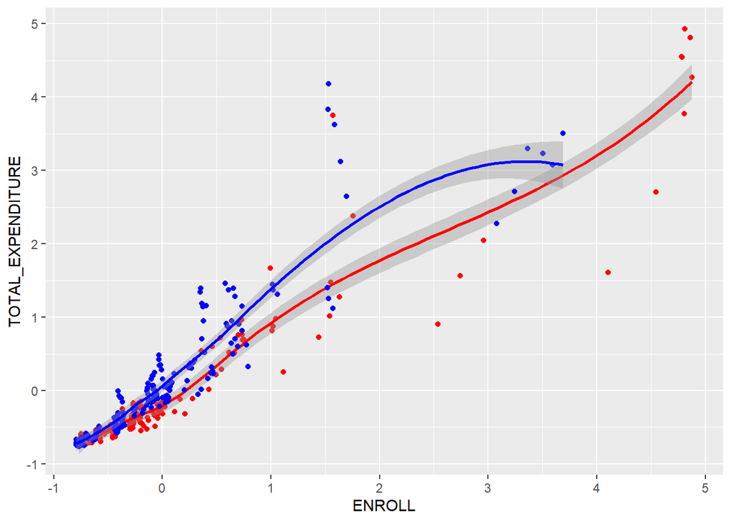

```r
####################################################################################
###################### VISUALIZE DATASET ###########################################
####################################################################################
# separate datasets to join in different colors
  # 2 classes
dfBelow <- df[df$Score2 == 'Below Average',]
dfAbove <- df[df$Score2 == 'Above Average',]
  # 3 classes
dfPoor <- df[df$Score3 == 'Poor',]
dfAverage <- df[df$Score3 == 'Average',]
dfGood <- df[df$Score3 == 'Good',]
# visualize 2 class dataset
Boundary2groups <- ggplot() +
  #below average
  geom_point(data=dfBelow, aes(y=TOTAL_EXPENDITURE, x=ENROLL), color="red")  +
  geom_smooth(data=dfBelow, aes(y=TOTAL_EXPENDITURE, x=ENROLL), color="red") +
  #above average
  geom_point(data=dfAbove, aes(y=TOTAL_EXPENDITURE, x=ENROLL), color='blue') +
  geom_smooth(data=dfAbove, aes(y=TOTAL_EXPENDITURE, x=ENROLL), color="blue")
Boundary2groups
```

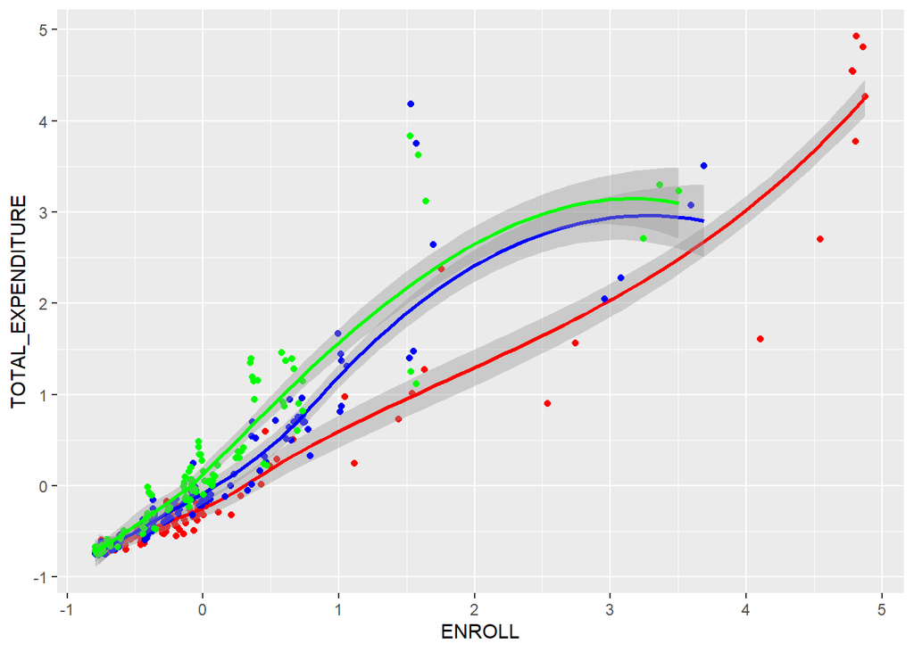

```r
# visualize 3 class dataset
Boundary3groups <- ggplot() +
  #poor
  geom_point(data=dfPoor, aes(y=TOTAL_EXPENDITURE, x=ENROLL), color="red")  +
  geom_smooth(data=dfPoor, aes(y=TOTAL_EXPENDITURE, x=ENROLL), color="red") +
  #average
  geom_point(data=dfAverage, aes(y=TOTAL_EXPENDITURE, x=ENROLL), color='blue') +
  geom_smooth(data=dfAverage, aes(y=TOTAL_EXPENDITURE, x=ENROLL), color="blue") +
  #good
  geom_point(data=dfGood, aes(y=TOTAL_EXPENDITURE, x=ENROLL), color='green') +
  geom_smooth(data=dfGood, aes(y=TOTAL_EXPENDITURE, x=ENROLL), color="green")
Boundary3groups
```

```r
####################################################################################
#################### MODELS ########################################################
####################################################################################
# create template x any y datasets
predictors <- df[,c(4:21,30:36)]
# 2 class y var
y2 <- df$Score2
# 3 class y var
y3 <- df$Score3
# create train and test datasets
split = round(nrow(df)*0.75)
train <- df[1:split,]
test <- df[(split+1):nrow(df),]
```

```r
######
# LINEAR REGRESSION
######
# df of selected predictors and y var
linearDF <- data.frame(train['ExpenditurePS'],train['ENROLL'], train['AggScore'])
# linear model
linear <- lm(AggScore ~., data = linearDF)
summary(linear)
```

```
##
## Call:
## lm(formula = AggScore ~ ., data = linearDF)
##
## Residuals:
##      Min       1Q   Median       3Q      Max
## -2.61095 -0.58845  0.02232  0.65460  1.62629
##
## Coefficients:
##               Estimate Std. Error t value Pr(>|t|)
## (Intercept)    0.02302    0.04717   0.488  0.62582
## ExpenditurePS  0.61840    0.04976  12.428  < 2e-16 ***
## ENROLL        -0.12579    0.04601  -2.734  0.00663 **
## ---
## Signif. codes:  0 '***' 0.001 '**' 0.01 '*' 0.05 '.' 0.1 ' ' 1
##
## Residual standard error: 0.8194 on 299 degrees of freedom
## Multiple R-squared:  0.3559, Adjusted R-squared:  0.3516
## F-statistic:  82.6 on 2 and 299 DF,  p-value: < 2.2e-16
```

```r
# predict test set and factorize predictions to compare with actual
linearPred <- predict.lm(linear, newdata = test)
linSum <- data.frame(linearPred, test$Score2, test$AggScore)
linSum['PredFac'] <- as.factor(ifelse(linSum$linearPred > mean(linSum$linearPred),
                                      'Above Average', 'Below Average'))
# get accuracy as ratio of hits to total rows
linearModAccuracy <- length(which(linSum['test.Score2'] == 'Below Average' &
                                    linSum['PredFac'] == 'Below Average'))/nrow(linSum)
# create vector for accuracy table at the end
lm <- c('Linear', round(linearModAccuracy, 2), NA)
```

Next up is the k-means algorithm. An unorthodoxed analysis had to be applied to this model in order to get the accuracy of the model’s “predictions” of the test dataset. The analysis is detailed in the comments of the program. As for the parameters of the models, all available algorithms were used and the most accurate is selected for the model. The number of classes selected corresponds with the number of classes in the test set. Maximum iterations was set at a value which optimizes both model computational cost and accuracy.

```r
#######
# K MEANS (fit whole df and use last 101 obvs for "prediction")
#######
# k means of 2 groups
kmeans2 <- kmeans(predictors, 2, iter.max = 100, nstart = 1,
                 algorithm = c("Hartigan-Wong", "Lloyd", "Forgy",
                               "MacQueen"), trace=FALSE)
# zip classifications and actuals
kmPred2 <- data.frame(y2, kmeans2$cluster)
# split predictions into "test" set
kmTrain2 <- kmPred2[1:split,]
kmTest2 <- kmPred2[(split+1):nrow(kmPred2),]
# create df to see which model class corresponds to which actual classification
BelowAverage = c(nrow(kmTrain2[kmTrain2$y2=='Below Average' & kmTrain2$kmeans2.cluster == 1,])
                 /nrow(kmTrain2[kmTrain2$kmeans2.cluster== 1,]),
         nrow(kmTrain2[kmTrain2$y2=='Below Average' & kmTrain2$kmeans2.cluster == 2,])
         /nrow(kmTrain2[kmTrain2$kmeans2.cluster== 2,]))
AboveAverage = c(nrow(kmTrain2[kmTrain2$y2=='Above Average' & kmTrain2$kmeans2.cluster == 1,])
                 /nrow(kmTrain2[kmTrain2$kmeans2.cluster== 1,]),
            nrow(kmTrain2[kmTrain2$y2=='Above Average' & kmTrain2$kmeans2.cluster == 2,])
            /nrow(kmTrain2[kmTrain2$kmeans2.cluster== 2,]))
kdf2 <- data.frame(BelowAverage,AboveAverage)
kdf2
```

```
##   BelowAverage AboveAverage
## 1    0.5714286    0.4285714
## 2    0.4377224    0.5622776
```

```r
# We find out which class the model is saying is Below and Above Average by selecting
#the class with the highest probability for each
below = which(kdf2['AboveAverage'] == max(kdf2$AboveAverage))
above = which(kdf2['BelowAverage'] == max(kdf2$BelowAverage))
# get model accuracy
kMeans2Accuracy <- (nrow(kmTest2[kmTest2$y2=='Below Average' & kmTest2$kmeans2.cluster == below,]) +
  nrow(kmTest2[kmTest2$y2=='Above Average' & kmTest2$kmeans2.cluster == above,])) / nrow(kmTest2)
# k means of 3 groups
kmeans3 <- kmeans(predictors, 3, iter.max = 100, nstart = 1,
                 algorithm = c("Hartigan-Wong", "Lloyd", "Forgy",
                               "MacQueen"), trace=FALSE)
kmPred3 <- data.frame(y3, kmeans3$cluster)
# split predictions into "test" set
kmTrain3 <- kmPred3[1:split,]
kmTest3 <- kmPred3[(split+1):nrow(kmPred3),]
# create df to see which model class corresponds to which actual classification
poor = c(nrow(kmTrain3[kmTrain3$y3=='Poor' & kmTrain3$kmeans3.cluster == 1,])
         /nrow(kmTrain3[kmTrain3$kmeans3.cluster== 1,]),
        nrow(kmTrain3[kmTrain3$y3=='Poor' & kmTrain3$kmeans3.cluster == 2,])
        /nrow(kmTrain3[kmTrain3$kmeans3.cluster== 2,]),
        nrow(kmTrain3[kmTrain3$y3=='Poor' & kmTrain3$kmeans3.cluster == 3,])
        /nrow(kmTrain3[kmTrain3$kmeans3.cluster== 3,]))
average = c(nrow(kmTrain3[kmTrain3$y3=='Average' & kmTrain3$kmeans3.cluster == 1,])
            /nrow(kmTrain3[kmTrain3$kmeans3.cluster== 1,]),
        nrow(kmTrain3[kmTrain3$y3=='Average' & kmTrain3$kmeans3.cluster == 2,])
        /nrow(kmTrain3[kmTrain3$kmeans3.cluster== 2,]),
        nrow(kmTrain3[kmTrain3$y3=='Average' & kmTrain3$kmeans3.cluster == 3,])
        /nrow(kmTrain3[kmTrain3$kmeans3.cluster== 3,]))
good = c(nrow(kmTrain3[kmTrain3$y3=='Good' & kmTrain3$kmeans3.cluster == 1,])
         /nrow(kmTrain3[kmTrain3$kmeans3.cluster== 1,]),
        nrow(kmTrain3[kmTrain3$y3=='Good' & kmTrain3$kmeans3.cluster == 2,])
        /nrow(kmTrain3[kmTrain3$kmeans3.cluster== 2,]),
        nrow(kmTrain3[kmTrain3$y3=='Good' & kmTrain3$kmeans3.cluster == 3,])
        /nrow(kmTrain3[kmTrain3$kmeans3.cluster== 3,]))
kdf3 <- data.frame(poor,average,good)
kdf3
```

```
##        poor   average      good
## 1 0.3472803 0.3054393 0.3472803
## 2 0.1875000 0.4166667 0.3958333
## 3 0.4666667 0.2666667 0.2666667
```

```r
# We find out which class the model is saying is Poor, Average, and Good by selecting
#the class with the highest probability for each
poor = which(kdf3['poor'] == max(kdf3$poor))
average = which(kdf3['average'] == max(kdf3$average))
good = ifelse(average == 1 & poor == 3,2,
        ifelse(average == 3 & poor == 1,2,
         ifelse(average == 2 & poor == 3,1,
          ifelse(average == 3 & poor == 2,1,
           ifelse(average == 2 & poor == 1,3,
            ifelse(average == 1 & poor == 2,3,NA))))))
# get model accuracy
kMeans3Accuracy <- (nrow(kmTest3[kmTest3$y3=='Good' & kmTest3$kmeans3.cluster == good,]) +
  nrow(kmTest3[kmTest3$y3=='Average' & kmTest3$kmeans3.cluster == average,]) +
  nrow(kmTest3[kmTest3$y3=='Poor' & kmTest3$kmeans3.cluster == poor,])) / nrow(kmTest3)
# create vector for accuracy table at the end
km <- c('k-Means', round(kMeans2Accuracy, 2), round(kMeans3Accuracy, 2))
```

A decision tree is used to predict the test set. minsplit and cp are set to values that minimize overfitting and thus, prediction accuracy.

```r
################
# decision tree
################
# split train and test datasets for DT models
splitPred = round(nrow(predictors)*0.75)
trainClass <- predictors[1:splitPred,]
testClass <- predictors[(splitPred+1):nrow(predictors),]
# y vars for 2 and 3 class
y2dtrain <- y2[1:302]
y3dtrain <- y3[1:302]
# join x and y datasets to use formula in RF function
dt2DF <- data.frame(trainClass, y2dtrain)
dt3DF <- data.frame(trainClass, y3dtrain)
# ensure no NAs
dt2df<-dt2DF[complete.cases(dt2DF),]
dt3df<-dt3DF[complete.cases(dt3DF),]
# make var names in test and train identical
testClass['S.D']=testClass['S/D']
testClass=testClass[,-24]
trainClass['S.D']=trainClass['S/D']
trainClass=trainClass[,-24]
# DT on 2 classes
# set control parameters
control=rpart.control(minsplit=50, cp=0.1)
# DT model
dt2 <- rpart(dt2DF$y2dtrain~., data = dt2df, method = 'class', control = control)
# get predictions, factorize, and compare to actuals
dt2pred <- predict(dt2, newdata = testClass)
dt2pred <- data.frame(dt2pred)
dt2pred['dt2predFac'] <- ifelse(dt2pred['Above.Average'] > 0.5, 'Above Average', 'Below Average')
y2dtest <- y2[303:403]
dt2pred <- data.frame(dt2pred, y2dtest)
# get model accuracy
dt2Accuracy <- (nrow(dt2pred[dt2pred$dt2predFac=='Below Average' &
                               dt2pred$y2dtest == 'Below Average',]) +
                      nrow(dt2pred[dt2pred$dt2predFac=='Above Average' &
                                     dt2pred$y2dtest == 'Above Average',])) / nrow(dt2pred)
# DT on 3
# set control parameters
control=rpart.control(minsplit=5, cp=0.01)
# DT model
dt3 <- rpart(dt3DF$y3dtrain~., data = dt3df, method = 'class', control = control)
# get predictions, factorize, and compare to actuals
dt3pred <- predict(dt3, newdata = testClass)
dt3pred <- data.frame(dt3pred)
dt3pred['dt3predFac'] <- ifelse(dt3pred['Good'] > dt3pred['Average'] &
                                  dt3pred['Good'] > dt3pred['Poor'], 'Good',
                                ifelse(dt3pred['Average'] > dt3pred['Good'] &
                                         dt3pred['Average'] > dt3pred['Poor'], 'Average',
                                       ifelse(dt3pred['Poor'] > dt3pred['Good'] &
                                                dt3pred['Poor'] > dt3pred['Average'], 'Poor',NA)))
y3dtest <- y3[303:403]
dt3pred <- data.frame(dt3pred, y3dtest)
# get model accuracy
dt3Accuracy <- (nrow(dt3pred[dt3pred$dt3predFac=='Good' & dt3pred$y3dtest == 'Good',]) +
                  nrow(dt3pred[dt3pred$dt3predFac=='Average' & dt3pred$y3dtest == 'Average',]) +
                     nrow(dt3pred[dt3pred$dt3predFac=='Poor' & dt3pred$y3dtest == 'Poor',])) /
                         nrow(dt3pred)
# create vector for accuracy table at the end
dt <- c('Decision Tree', round(dt2Accuracy, 2), round(dt3Accuracy, 2))
```

Next we use a naive bayes model. The accuracy of this model on predicting classifications of the test set was robust, meaning that laplace smoothing had a negligible effect on accuracy. Therefore, laplace smoothing was set to +1 to prevent multipliers of 0 value and the rest of the model is default.

```r
################
# naive Bayes
################
# naive Bayes on 2 classes
# x and y datasets for 2 class NB model
nb2trainX <- trainClass
nb2trainY <- y2[1:302]
# Naive Bayes model
nb2Model <- naiveBayes(nb2trainX, nb2trainY, laplace = 1)
# get predictions and compare to actuals
nb2Pred <- predict(nb2Model, newdata = testClass)
nb2Tfac <- y2[303:403]
nb2Pred <- data.frame(nb2Pred,nb2Tfac)
# get model accuracy
nb2Accuracy <- (nrow(nb2Pred[nb2Pred$nb2Pred=='Below Average' &
                               nb2Pred$nb2Tfac == 'Below Average',]) +
                  nrow(nb2Pred[nb2Pred$nb2Pred=='Above Average' &
                                 nb2Pred$nb2Tfac == 'Above Average',]))/
                                     nrow(nb2Pred)
# naive Bayes on 3 classes
# x and y datasets for 3 class NB model
nb3trainX <- trainClass
nb3trainY <- y3[1:302]
# Naive Bayes model
nb3Model <- naiveBayes(nb3trainX, nb3trainY, laplace = 1)
# get predictions and compare to actuals
nb3Pred <- predict(nb3Model, newdata = testClass)
nb3Tfac <- y3[303:403]
nb3Pred <- data.frame(nb3Pred,nb3Tfac)
# get model accuracy
nb3Accuracy <- (nrow(nb3Pred[nb3Pred$nb3Pred=='Good' &
                               nb3Pred$nb3Tfac == 'Good',]) +
                  nrow(nb3Pred[nb3Pred$nb3Pred=='Average' &
                                 nb3Pred$nb3Tfac == 'Average',]) +
                     nrow(nb3Pred[nb3Pred$nb3Pred=='Poor' &
                                    nb3Pred$nb3Tfac == 'Poor',]))/
                                       nrow(nb3Pred)
# create vector for accuracy table at the end
nb <- c('Naive Bayes',round(nb2Accuracy, 2), round(nb3Accuracy, 2))
```

A support vector machine is built next to predict the test set classifications. Interestingly, a linear kernel was much less accurate in the 3 class predictions than a radial kernel, and the results of radial and linear kernels were very similar in the 2 class predictions. Relatively high gamma values are set to prevent the model from overfitting (using low gamma values causes a single example in the training process to reach “further” than higher values allow) and to increase prediction accuracy as a result.

```r
################
# SVM
################
#SVM on 2 classes
# x and y datasets for 2 class SVM model
svm2trainX <- trainClass
svm2trainY <- y2[1:302]
# SVM model
svm2Model <- svm(svm2trainX, svm2trainY, kernel = "radial", gamma = 0.5)
# get predictions and compare to actuals
svm2Pred <- predict(svm2Model, newdata = testClass)
svm2Tfac <- y2[303:403]
svm2Pred <- data.frame(svm2Pred,svm2Tfac)
# get model accuracy
svm2Accuracy <- (nrow(svm2Pred[svm2Pred$svm2Pred=='Below Average' &
                                 svm2Pred$svm2Tfac == 'Below Average',]) +
                  nrow(svm2Pred[svm2Pred$svm2Pred=='Above Average' &
                                  svm2Pred$svm2Tfac == 'Above Average',]))/
                                     nrow(svm2Pred)
#SVM on 3 classes
# x and y datasets for 3 class SVM model
svm3trainX <- trainClass
svm3trainY <- y3[1:302]
# SVM model
svm3Model <- svm(svm3trainX, svm3trainY, kernel = "radial", gamma = 0.75)
# get predictions and compare to actuals
svm3Pred <- predict(svm3Model, newdata = testClass)
svm3Tfac <- y3[303:403]
svm3Pred <- data.frame(svm3Pred,svm3Tfac)
# get model accuracy
svm3Accuracy <- (nrow(svm3Pred[svm3Pred$svm3Pred=='Good' &
                                 svm3Pred$svm3Tfac == 'Good',]) +
                  nrow(svm3Pred[svm3Pred$svm3Pred=='Average' &
                                  svm3Pred$svm3Tfac == 'Average',]) +
                  nrow(svm3Pred[svm3Pred$nb3svm3PredPred=='Poor' &
                                  svm3Pred$svm3Tfac == 'Poor',])) /
                                       nrow(svm3Pred)
# create vector for accuracy table at the end
svm <- c('Support Vector Machine', round(svm2Accuracy, 2), round(svm3Accuracy, 2))
```

A k-Nearest Neighbor algorithm is used next. k values were determined by the highest prediction accuracy. Interestingly, k=1 in the 2 class model resulted in the highest accuracy of all other k-values attempted, and actually resulted in one the most accurate 2 class predictions in this project at roughly 80%.

```r
################
# kNN
################
# kNN on 2 classes
# y var for knn 2 class model
cl2 =  as.vector(y2[1:302])
#kNN model
knn2Model <- knn(trainClass, testClass, cl2, k=1)
# get predictions and compare to actuals
knn2Tfac <- y2[303:403]
knn2Pred <- data.frame(knn2Model,knn2Tfac)
# get model accuracy
knn2Accuracy <- (nrow(knn2Pred[knn2Pred$knn2Model=='Below Average' &
                                 knn2Pred$knn2Tfac == 'Below Average',]) +
                   nrow(knn2Pred[knn2Pred$knn2Model=='Above Average' &
                                   knn2Pred$knn2Tfac == 'Above Average',]))/
                                       nrow(knn2Pred)
#kNN on 3 classes
# y var for knn 2 class model
cl3 =  as.vector(y3[1:302])
#kNN model
knn3Model <- knn(trainClass, testClass, cl3, k=4)
# get predictions and compare to actuals
knn3Tfac <- y3[303:403]
knn3Pred <- data.frame(knn3Model,knn3Tfac)
# get model accuracy
knn3Accuracy <- (nrow(knn3Pred[knn3Pred$knn3Model=='Good' &
                                 knn3Pred$knn3Tfac == 'Good',]) +
                   nrow(knn3Pred[knn3Pred$knn3Model=='Average' &
                                   knn3Pred$knn3Tfac == 'Average',]) +
                   nrow(knn3Pred[knn3Pred$knn3Model=='Poor' &
                                   knn3Pred$knn3Tfac == 'Poor',])) /
                                       nrow(knn3Pred)
# create vector for accuracy table at the end
knn <- c('k-Nearest-Neighbors', round(knn2Accuracy, 2), round(knn3Accuracy, 2))
```

Finally, we implement a random forest model on the 2 and 3 class datasets. These models took the longest to compute (there was a negligible difference in computation time of all other models), but are also the most accurate on average. values for ntree, mtry, and maxnodes were set to maximize prediction accuracy on the test set and minimize computational load.

```r
################
# Random Forest
################
# Random Forest on 2 classes
# y var for 2 class RF model
rfy2 =  as.factor(y2[1:302])
# Random Forest Model
rf2Model <- randomForest(trainClass, rfy2, ntree = 750, mtry = 5, maxnodes = 200)
# get predictions and compare to actuals
rf2predic <- as.factor(predict(rf2Model, testClass))
rf2Tfac <- y2[303:403]
# get model accuracy
rf2Accuracy <- sum(rf2predic == rf2Tfac) / length(rf2predic)
# Random Forest on 3 classes
# y var for 3 class RF model
rfy3 =  as.factor(y3[1:302])
# Random Forest Model
rf3Model <- randomForest(trainClass, rfy3, ntree = 750, mtry = 5, maxnodes = 250)
# get predictions and compare to actuals
rf3predic <- as.factor(predict(rf3Model, testClass))
rf3Tfac <- y3[303:403]
# get model accuracy
rf3Accuracy <- sum(rf3predic == rf3Tfac) / length(rf3predic)
# create vector for accuracy table at the end
rf <- c('Random Forest', round(rf2Accuracy, 2), round(rf3Accuracy, 2))
```

Now that all the models are built, tuned, used to predict the test set, and subsequently evaluated on the accuracy metric, we tabulate their accuracies on the 2 class and 3 class predictions for simple comparison. Keep in mind that all the accuracies on the table reflect each model’s most accurate predictions, given several trial runs of different tuning parameters for each. Therefore, we can confidently evaluate which model is best suited for this dataset.

```r
################
# table of model accuracies
################
# y2 y3 lm2 km2 km3 dt2 dt3 nb2 nb3 svm2 svm3 knn2 knn3 rf2 rf3
cols <- c('Model', 'Accuracy (2 Classes)', 'Accuracy (3 Classes)')
accuracies <- data.frame(cols, lm, km, dt, nb, svm, knn, rf)
accuracies
```

Model Prediction Accuracies

| cols | lm | km | dt | nb | svm | knn | rf |
| --- | --- | --- | --- | --- | --- | --- | --- |
| Model | Linear | k-Means | Decision Tree | Naive Bayes | Support Vector Machine | k-Nearest-Neighbors | Random Forest |
| Accuracy (2 Classes) | 0.36 | 0.46 | 0.72 | 0.51 | 0.76 | 0.81 | 0.79 |
| Accuracy (3 Classes) | NA | 0.29 | 0.58 | 0.49 | 0.46 | 0.63 | 0.66 |